# Tutorial: Factors

### **P4 REEU // Natalie Nelson, PhD**

### 1. Overview and learning objectives

This tutorial reviews **factors**, a data type in R, and functions in the `forcats` package. The `forcats` package is in the `tidyverse` family of packages and includes functions specifically for working with factors. This tutorial is closely derived from [Chapter 15 Factors](https://r4ds.had.co.nz/factors.html) in R for Data Science by Garrett Grolemund and Hadley Wickham.

After completing this module, you will be able to:

- Define: factors, levels
- Apply the following functions: `factor()`, `levels()`, `fct_recode()`, `fct_relevel()`, `fct_reorder()`

**Let’s get started!** 🚀

```r
library(tidyverse)
```

### 2. What are factors?

Factors are a data type or class in R, just like character, double, integer, and logical. The factor data type is used when working with **categorical** data. Categorical data consist of groups/categories. For example, the Palmer Penguins dataset includes several factor columns, shown as `<fctr>` when the first few rows are previewed:

```r
# Load the palmerpenguins package, which includes the penguins dataset
library(palmerpenguins)
# Look at the head of penguins
head(penguins)
```

```
## # A tibble: 6 x 8
##   species island bill_length_mm bill_depth_mm flipper_length_… body_mass_g sex
##   <fct>   <fct>           <dbl>         <dbl>            <int>       <int> <fct>
## 1 Adelie  Torge…           39.1          18.7              181        3750 male
## 2 Adelie  Torge…           39.5          17.4              186        3800 fema…
## 3 Adelie  Torge…           40.3          18                195        3250 fema…
## 4 Adelie  Torge…           NA            NA                 NA          NA <NA>
## 5 Adelie  Torge…           36.7          19.3              193        3450 fema…
## 6 Adelie  Torge…           39.3          20.6              190        3650 male
## # … with 1 more variable: year <int>
```

`species`, `island`, and `sex` are factor vectors, meaning these columns consist of categorical data. If we run `unique(penguins$species)`, we can see that categories in `species` include: `Adelie`, `Gentoo`, and `Chinstrap`. Each unique species represented in the dataset is one category. You will also see something new in the output: `Levels: Adelie Chinstrap Gentoo`. We’ll review this in a moment.

Similarly, the `island` column includes each unique location as a category: `Torgersen`, `Biscoe`, `Dream`. `sex` includes two categories, `male` and `female`, or three if you count `NA` as a unique category.

Factors are usually composed of **character** (`<chr>`) data, but differ from character data in that there are defined **levels** that correspond to the unique categories in the data. Numeric (`<dbl>`, `<int>`) data can also be treated as factors with unique levels, but R cannot perform mathematical operations on factors. As a result, if a numeric vector is converted to a factor, R will treat the vector as character data.

The key advantage to working with factors is the ability to manipulate levels, or categories, represented in the data. The rest of this tutorial will focus on creating factors, defining levels, and reordering levels.

### 3. Converting a column to a factor: `factor()`

Imagine you have a character vector composed of a few months:

```r
x <- c("Dec", "Apr", "Jan", "Mar")
```

This vector is included in a dataframe with values corresponding to a set of measurements:

```r
d <- data.frame(months = x,
                measurements = c(4, 2, 7, 1))
d
```

```
##   months measurements
## 1    Dec            4
## 2    Apr            2
## 3    Jan            7
## 4    Mar            1
```

If we made a barplot to visualize the data (months mapped to the x-axis, measurements mapped to the y-axis), the months would sort in alphabetical order by default:

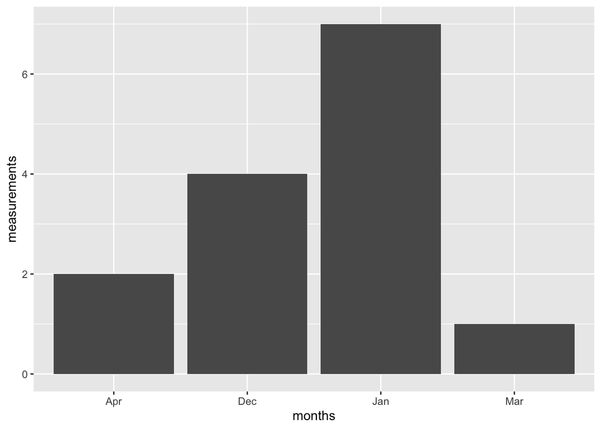

```r
ggplot(data = d) +
  geom_bar(mapping = aes(x = months, y = measurements),
           stat = "identity")
```

To change the order of the months, we have to specify an order to the categories or levels in the `months` column. We can fix this issue by converting the `months` column to a factor using the `factor()` function. `factor()` includes many arguments that can be specified, but at a minimum only requires the column to be converted.

```r
# Apply the factor function to a vector object
x_fct <- factor(x)
x_fct
```

```
## [1] Dec Apr Jan Mar
## Levels: Apr Dec Jan Mar
```

`factor()` can also be used with dataframes:

```r
# Apply the factor function to a dataframe column
factor(d$months)
# Here we are just looking at the output, we would
# have to redefine d$months for the column to be
# converted to a factor

# Create a new column with month as a factor
d %>%
  mutate(months_factor = factor(months))
# Again, we are just looking at the output, we
# have not redefined d to include this column yet
```

If you look at the contents of `x_fct` in the console, you will see that, in addition to the contents of the vector, the levels are also shown as `Levels: Apr Dec Jan Mar`. Here, the unique levels included in the data are shown and listed in the order that R has sorted them by default (which is alphabetical). The order of the levels also reflects the order in which the months were plotted in the barplot above.

Rather than have the `factor()` function default to ordering the levels alphabetically, we can specify what the levels are using the `levels =` argument. The `levels =` argument requires a **vector** of the level names included in quotation marks. R will preserve the order in which the levels are specified.

```r
x_fct2 <- factor(x,
                levels = c("Jan", "Mar", "Apr", "Dec"))
x_fct2
```

```
## [1] Dec Apr Jan Mar
## Levels: Jan Mar Apr Dec
```

The order of the levels will transfer to the plot:

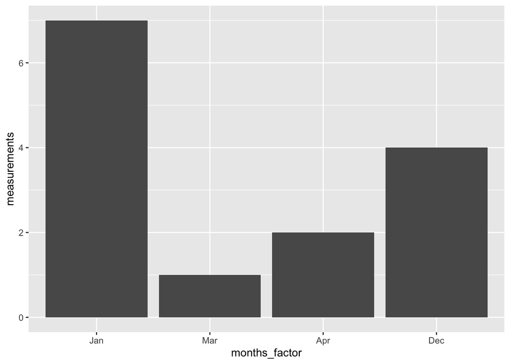

```r
d %>%
  mutate(months_factor = factor(months,
                                levels = c("Jan", "Mar", "Apr", "Dec"))) %>%
  ggplot() +
  geom_bar(mapping = aes(x = months_factor, y = measurements),
           stat = "identity")
```

#### 3.1. Working with numeric factor data

In section 2, I said you could convert numeric data to factors, but that R would treat the factor data as characters. Which is to say, mathematical operations could not be applied to the numeric factors. As a result, converting a numeric vector to a factor fundamentally changes how the vector can be handled; the values in the vector are essentially treated as category labels instead of numbers. This contrasts with character vectors: when a character vector is converted to a factor, the way R treats the data is essentially unchanged, except R will recognize that there are specific levels in the vector.

Below, an example is shown in which R throws an error message after trying to apply a mathematical operation to a vector of integers.

```r
# Create an integer vector
numbers <- c(1, 2, 3, 4, 5)
# Convert to a factor
numbers_fct <- factor(numbers)
# Inspect the data type and class:
# Note that R recognizes the data
# are integers, but also factors
str(numbers_fct)
```

```
##  Factor w/ 5 levels "1","2","3","4",..: 1 2 3 4 5
```

```r
typeof(numbers_fct)
```

```
## [1] "integer"
```

```r
class(numbers_fct)
```

```
## [1] "factor"
```

```r
# Can't apply mathematical functions
# to the factor
sum(numbers)
sum(numbers_fct)
numbers^2
numbers_fct^2
```

[output not shown]

### 4. Specifying extra levels

Another special feature of factors is that factor levels can include categories that are not represented in the data. For example, instead of defining the levels for `x_fct` as the months represented in the data (only Apr, Dec, Jan, and Mar), we could have instead defined the levels to include all conceivable categories:

```r
x_fct3 <- factor(x,
                levels = c(
                  "Jan", "Feb", "Mar",
                  "Apr", "May", "Jun",
                  "Jul", "Aug", "Sep",
                  "Oct", "Nov", "Dec"
                ))
x_fct3
```

```
## [1] Dec Apr Jan Mar
## Levels: Jan Feb Mar Apr May Jun Jul Aug Sep Oct Nov Dec
```

Why would you specify all conceivable levels? There are two main reasons I am aware of:

- **Quality control**: When you specify factor levels, you are also specifying which values can be included in the vector. If R encounters a value in the vector that is not included in the defined levels, it will replace the value with `NA`. As a result, we can use levels to flag problematic or inconsistent entries (e.g. typos):

```r
x_typo <- c("Dec", "Apr", "Jam", "Mar", "October")

factor(x_typo,
       levels = c(
         "Jan", "Feb", "Mar",
         "Apr", "May", "Jun",
         "Jul", "Aug", "Sep",
         "Oct", "Nov", "Dec"
       ))
```

```
## [1] Dec  Apr  <NA> Mar  <NA>
## Levels: Jan Feb Mar Apr May Jun Jul Aug Sep Oct Nov Dec
```

- **Save time for future-you**: Defining factors is often done as part of the data cleaning process when you’re first reading your data into R. Two key advantages to running data analyses with scripts as opposed to point-and-click software programs is that you can quickly re-run analyses as new data are generated, and apply your scripts to other datasets. To avoid having to edit your code each time new data are created or each time you want to apply your script to a new dataset, you can define the levels to include all expected values. Your future self will thank you.

### 5. Inspect levels: `levels()`

To inspect a factor vector’s levels and level order, you can use the `levels()` function. The `levels()` function only requires one argument: the name of the factor vector you wish to inspect. `levels()` differs from `unique()` in that it shows all defined levels in the order they were specified (or, if the levels were not specified, they will be shown in alphabetical order). The output to `unique()` shows unique values included in the vector, and the values are printed in the order in which they occur in the vector.

```r
q <- c("Apr", "May", "Jan",
       "Jan", "Nov", "Jul")
q_fct <- factor(q,
                levels = c(
                  "Jan", "Feb", "Mar",
                  "Apr", "May", "Jun",
                  "Jul", "Aug", "Sep",
                  "Oct", "Nov", "Dec"
                ))
levels(q_fct)
```

```
##  [1] "Jan" "Feb" "Mar" "Apr" "May" "Jun" "Jul" "Aug" "Sep" "Oct" "Nov" "Dec"
```

```r
unique(q_fct)
```

```
## [1] Apr May Jan Nov Jul
## Levels: Jan Feb Mar Apr May Jun Jul Aug Sep Oct Nov Dec
```

### 6. Recoding factor values: `fct_recode()`

If you want to change factor level names, which will also change the names in your dataframe object, you can use the `fct_recode()` function. You unfortunately cannot pipe directly into this function unless you specifically pipe a single column (see example below). Instead, you have to use it with `mutate()`. Note that, with the `mutate()` function, if you define a column name that already exists in the dataframe, the column will just be overwritten; mutate will not add a new column unless the column has a distinct name. This can be seen in the example below.

The arguments to `fct_recode()` are structured as follows:

```r
fct_recode(
  dataframe$column_name,
  "New name for level 1" = "Current name of level 1",
  "New name for level 2" = "Current name of level 2"
)
```

As an example, we can recode the factor levels in the `island` column of the `penguins` dataframe. Here, we will add “Island” to the name of each island, e.g. `"Biscoe"` will become `"Biscoe Island"`.

```r
penguins %>%
  mutate(island = fct_recode(island,
                             "Biscoe Island" = "Biscoe",
                             "Dream Island" = "Dream",
                             "Torgersen Island" = "Torgersen")) -> penguins_fct
penguins_fct
```

```
## # A tibble: 344 x 8
##    species island      bill_length_mm bill_depth_mm flipper_length_… body_mass_g
##    <fct>   <fct>                <dbl>         <dbl>            <int>       <int>
##  1 Adelie  Torgersen …           39.1          18.7              181        3750
##  2 Adelie  Torgersen …           39.5          17.4              186        3800
##  3 Adelie  Torgersen …           40.3          18                195        3250
##  4 Adelie  Torgersen …           NA            NA                 NA          NA
##  5 Adelie  Torgersen …           36.7          19.3              193        3450
##  6 Adelie  Torgersen …           39.3          20.6              190        3650
##  7 Adelie  Torgersen …           38.9          17.8              181        3625
##  8 Adelie  Torgersen …           39.2          19.6              195        4675
##  9 Adelie  Torgersen …           34.1          18.1              193        3475
## 10 Adelie  Torgersen …           42            20.2              190        4250
## # … with 334 more rows, and 2 more variables: sex <fct>, year <int>
```

```r
levels(penguins_fct$island)
```

```
## [1] "Biscoe Island"    "Dream Island"     "Torgersen Island"
```

Alternatively, instead of using a pipeline as shown above, you can also redefine the column in the dataframe:

```r
penguins$island <- fct_recode(penguins$island,
                              "Biscoe Island" = "Biscoe",
                              "Dream Island" = "Dream",
                              "Torgersen Island" = "Torgersen")
```

Or pipe the column vector into `fct_recode()`:

```r
penguins$island %>%
  fct_recode("Biscoe Island" = "Biscoe",
             "Dream Island" = "Dream",
             "Torgersen Island" = "Torgersen")
```

### 7. Reordering factor levels: `fct_reorder()`, `fct_relevel()`

As you work on an analysis, you may discover that you would like to reorder factor levels. This typically occurs in the process of creating a data visualization. Before diving into reordering levels, let’s start with an example. A Bob Ross example. For those of you who aren’t familiar with Bob Ross, he was a painter who hosted a TV show called “The Joy of Painting.” He has been described as the “[ultimate calming presence.](https://www.theatlantic.com/culture/archive/2020/07/why-bob-ross-still-so-popular/614431/)”

[figure not shown]

In 2014, Walt Hickey published [*A Statistical Analysis of the Work of Bob Ross*](https://fivethirtyeight.com/features/a-statistical-analysis-of-the-work-of-bob-ross/) on FiveThirtyEight, a data journalism organization. Walt’s study sought to answer the question: which features showed up most frequently in the 403 episodes of “The Joy of Painting”? Happy little trees? Fluffy clouds? The dataset he created to perform this analysis is included in the [`fivethirtyeight`](https://cran.r-project.org/web/packages/fivethirtyeight/vignettes/fivethirtyeight.html) package as a dataframe object, `bob_ross`. Load `fivethirtyeight` and `bob_ross` to your workspace, and use the code below to summarize and plot the data. The dataset is organized such that there is one row per episode, and one column for each keyword characterizing the episode. The keywords describe painted elements (e.g., aurora_borealis, beach), stylistic choices in framing the paintings, and guest artists. In the keyword columns, there is either a 1 or 0 to indicate whether the keyword did or did not apply to the episode, respectively.

With the code below, you will collapse the keyword columns into two: `keyword` and `count`. The `count` column will include the total number of times the keywords described the 403 episodes. The long-format data will be saved to a new object named `bob_ross_features`. The `keyword` column is then converted to a factor and the levels are not specified, meaning they will be ordered alphabetically by default. These data are then plotted.

```r
library(fivethirtyeight)
# Summarize
bob_ross %>%
  pivot_longer(apple_frame:wood_framed,
               names_to = "keyword",
               values_to = "count") %>%
  group_by(keyword) %>%
  summarize(count = sum(count)) %>%
  ungroup() -> bob_ross_features
# Convert the keyword column to a factor
bob_ross_features$keyword <- factor(bob_ross_features$keyword)
levels(bob_ross_features$keyword)
```

```
##  [1] "apple_frame"        "aurora_borealis"    "barn"
##  [4] "beach"              "boat"               "bridge"
##  [7] "building"           "bushes"             "cabin"
## [10] "cactus"             "circle_frame"       "cirrus"
## [13] "cliff"              "clouds"             "conifer"
## [16] "cumulus"            "deciduous"          "diane_andre"
## [19] "dock"               "double_oval_frame"  "farm"
## [22] "fence"              "fire"               "florida_frame"
## [25] "flowers"            "fog"                "framed"
## [28] "grass"              "guest"              "half_circle_frame"
## [31] "half_oval_frame"    "hills"              "lake"
## [34] "lakes"              "lighthouse"         "mill"
## [37] "moon"               "mountain"           "mountains"
## [40] "night"              "ocean"              "oval_frame"
## [43] "palm_trees"         "path"               "person"
## [46] "portrait"           "rectangle_3d_frame" "rectangular_frame"
## [49] "river"              "rocks"              "seashell_frame"
## [52] "snow"               "snowy_mountain"     "split_frame"
## [55] "steve_ross"         "structure"          "sun"
## [58] "tomb_frame"         "tree"               "trees"
## [61] "triple_frame"       "waterfall"          "waves"
## [64] "windmill"           "window_frame"       "winter"
## [67] "wood_framed"
```

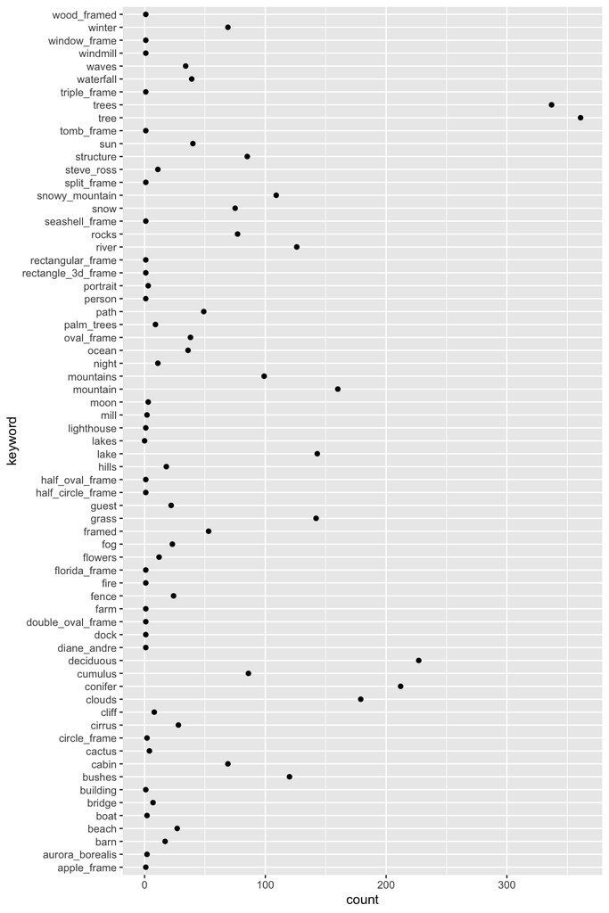

```r
# Visualize
ggplot(data = bob_ross_features) +
  geom_point(mapping = aes(x = count, y = keyword))
```

From the plot, we can see that there are a few keywords that more commonly describe The Joy of Painting episodes. It takes some effort to read the plot and determine which keywords show up most frequently. To make the plot easier to read, we can **reorder** the keyword factor levels so that the levels are sorted based on values in the `count` column.

To reorder the keyword levels based on values in the `count` column, we can use `fct_reorder()`. The arguments to `fct_reorder()` include the factor vector you want to modify, and a **numeric** vector you want to use to reorder the levels. In this case, the factor vector we want to reorder is `bob_ross_features$keyword`, and the numeric vector we want to use to reorder the factor levels is `bob_ross_features$count`.

```r
# Levels before reordering:
levels(bob_ross_features$keyword)
```

```
##  [1] "apple_frame"        "aurora_borealis"    "barn"
##  [4] "beach"              "boat"               "bridge"
##  [7] "building"           "bushes"             "cabin"
## [10] "cactus"             "circle_frame"       "cirrus"
## [13] "cliff"              "clouds"             "conifer"
## [16] "cumulus"            "deciduous"          "diane_andre"
## [19] "dock"               "double_oval_frame"  "farm"
## [22] "fence"              "fire"               "florida_frame"
## [25] "flowers"            "fog"                "framed"
## [28] "grass"              "guest"              "half_circle_frame"
## [31] "half_oval_frame"    "hills"              "lake"
## [34] "lakes"              "lighthouse"         "mill"
## [37] "moon"               "mountain"           "mountains"
## [40] "night"              "ocean"              "oval_frame"
## [43] "palm_trees"         "path"               "person"
## [46] "portrait"           "rectangle_3d_frame" "rectangular_frame"
## [49] "river"              "rocks"              "seashell_frame"
## [52] "snow"               "snowy_mountain"     "split_frame"
## [55] "steve_ross"         "structure"          "sun"
## [58] "tomb_frame"         "tree"               "trees"
## [61] "triple_frame"       "waterfall"          "waves"
## [64] "windmill"           "window_frame"       "winter"
## [67] "wood_framed"
```

```r
# Reorder by values in the count column
bob_ross_features$keyword <-
  fct_reorder(bob_ross_features$keyword,
              bob_ross_features$count)
# Levels after reordering:
levels(bob_ross_features$keyword)
```

```
##  [1] "lakes"              "apple_frame"        "building"
##  [4] "diane_andre"        "dock"               "double_oval_frame"
##  [7] "farm"               "fire"               "florida_frame"
## [10] "half_circle_frame"  "half_oval_frame"    "lighthouse"
## [13] "person"             "rectangle_3d_frame" "rectangular_frame"
## [16] "seashell_frame"     "split_frame"        "tomb_frame"
## [19] "triple_frame"       "windmill"           "window_frame"
## [22] "wood_framed"        "aurora_borealis"    "boat"
## [25] "circle_frame"       "mill"               "moon"
## [28] "portrait"           "cactus"             "bridge"
## [31] "cliff"              "palm_trees"         "night"
## [34] "steve_ross"         "flowers"            "barn"
## [37] "hills"              "guest"              "fog"
## [40] "fence"              "beach"              "cirrus"
## [43] "waves"              "ocean"              "oval_frame"
## [46] "waterfall"          "sun"                "path"
## [49] "framed"             "cabin"              "winter"
## [52] "snow"               "rocks"              "structure"
## [55] "cumulus"            "mountains"          "snowy_mountain"
## [58] "bushes"             "river"              "grass"
## [61] "lake"               "mountain"           "clouds"
## [64] "conifer"            "deciduous"          "trees"
## [67] "tree"
```

Note that, when reordering factor levels, the order of values in the dataframe remains unchanged. All we are changing is the way in which R sorts the level names.

Now that the data are reordered, let’s plot the data once again:

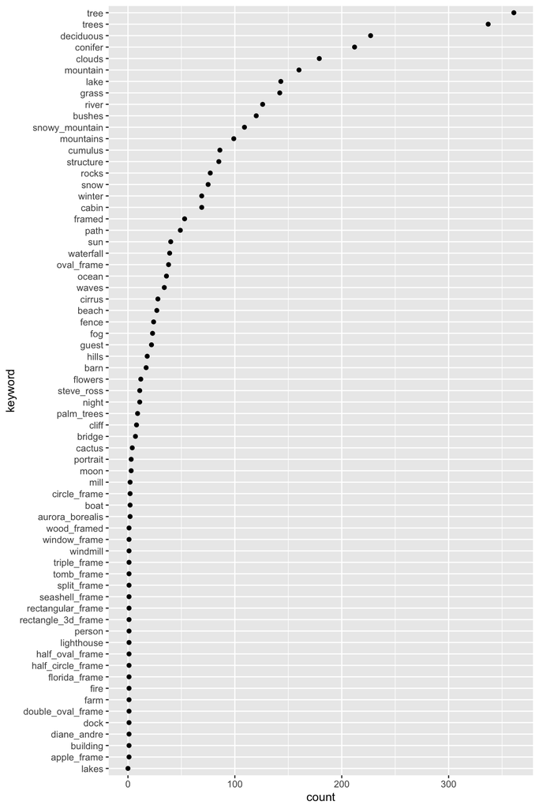

```r
ggplot(data = bob_ross_features) +
  geom_point(mapping = aes(x = count, y = keyword))
```

This reordered plot makes it easier to see that the keywords most commonly describing episodes were (happy little) trees by far, followed by clouds, mountains, and lakes.

Another handy function for reordering factor levels is `fct_relevel()`. `fct_relevel()` is a bit more versatile than `fct_reorder()` in that it can reorder levels in a few ways.

The most simple use of `fct_relevel()` is to specify a **new position(s)** for a level(s). The help documentation for `fct_relevel()` uses the following example:

```r
f <- factor(c("a", "b", "c", "d"), levels = c("b", "c", "d", "a"))
fct_relevel(f, "a")
```

```
## [1] a b c d
## Levels: a b c d
```

```r
fct_relevel(f, "b", "a")
```

```
## [1] a b c d
## Levels: b a c d
```

In this example, `fct_relevel(f, "a")` is used to bring “a” to the first level position. `fct_relevel(f, "b", "a")` is used to bring “b” to the first level position, and “a” to the second level position. When `fct_relevel()` is used in this way, without specifying additional arguments, the function assumes you want to bring the specified levels to the first level positions.

Alternatively, you can specify the precise location of the level using an argument `after =`. With this argument, you indicate which level position comes before the position you want to move the level to. For example, if we wrote `fct_relevel(f, "a", after = 2)`, this code would be interpreted as: move level “a” after the second level position. Said another way, move level “a” to the third position. If you want to move the level to the **last** level position, set `after =` to `Inf` (which stands for “infinity”).

```r
# Move to the second position
fct_relevel(f, "a", after = 1)
```

```
## [1] a b c d
## Levels: b a c d
```

```r
# Relevel to the end
fct_relevel(f, "c", after = Inf)
```

```
## [1] a b c d
## Levels: b d a c
```

```r
k <- factor(c("bravo", "delta", "foxtrot",
              "echo", "alfa", "charlie"),
            levels = c("bravo", "delta", "foxtrot",
              "echo", "alfa", "charlie"))
levels(k)
```

```
## [1] "bravo"   "delta"   "foxtrot" "echo"    "alfa"    "charlie"
```

```r
# Sort levels in ascending order (i.e. alphabetical)
fct_relevel(k, sort)
```

```
## [1] bravo   delta   foxtrot echo    alfa    charlie
## Levels: alfa bravo charlie delta echo foxtrot
```

```r
# Sort levels in reverse order
fct_relevel(k, rev)
```

```
## [1] bravo   delta   foxtrot echo    alfa    charlie
## Levels: charlie alfa echo foxtrot delta bravo
```

### Exercises

**Exercise 1.** The `species` column in `penguins` includes the following levels: `Adelie`, `Gentoo`, and `Chinstrap`. These levels correspond to “common names” for these species. Change the level names so that they are instead labelled as the scientific species names:

- Adelie: Pygoscelis adeliae
- Gentoo: Pygoscelis papua
- Chinstrap: Pygoscelis antarctica

```r
levels(penguins$species)
```

```
## [1] "Pygoscelis adeliae"    "Pygoscelis antarctica" "Pygoscelis papua"
```

**Exercise 2.** Create the following dataframe:

```r
h <-
  data.frame(hurricane = c("Hazel", "Connie", "Ione",
                           "Great Atlantic Hurricane",
                           "Helene", "Donna",  "Fran",
                           "Diana", "Emily"),
             category = c(4, 3, 3, 3, 3, 3, 3, 3, 3),
             landfall_year = c(1954, 1955, 1955,
                               1944, 1958, 1960,
                               1996, 1984, 1993))
```

- Convert `hurricane` in `h` to a factor, and specify the labels such that they are ordered in the way that they occur in the dataframe.

```r
levels(h$hurricane)
```

```
## [1] "Hazel"                    "Connie"
## [3] "Ione"                     "Great Atlantic Hurricane"
## [5] "Helene"                   "Donna"
## [7] "Fran"                     "Diana"
## [9] "Emily"
```

- Using one of the `fct_` functions, reorder the `hurricane` factor levels so that they are sorted in alphabetical order.

```r
levels(h$hurricane)
```

```
## [1] "Connie"                   "Diana"
## [3] "Donna"                    "Emily"
## [5] "Fran"                     "Great Atlantic Hurricane"
## [7] "Hazel"                    "Helene"
## [9] "Ione"
```

- Using one of the `fct_` functions, reorder the `hurricane` factor levels so that they are sorted based on the year in which they made landfall.

```r
levels(h$hurricane)
```

```
## [1] "Great Atlantic Hurricane" "Hazel"
## [3] "Connie"                   "Ione"
## [5] "Helene"                   "Donna"
## [7] "Diana"                    "Emily"
## [9] "Fran"
```

- Using the `fct_` functions, reorder the `hurricane` factor levels so that they are sorted in reverse alphabetical order.

```r
levels(h$hurricane)
```

```
## [1] "Ione"                     "Helene"
## [3] "Hazel"                    "Great Atlantic Hurricane"
## [5] "Fran"                     "Emily"
## [7] "Donna"                    "Diana"
## [9] "Connie"
```

### Attribution and license

Material in this tutorial is closely derived from [R for Data Science](https://r4ds.had.co.nz/) by Garrett Gromelund and Hadley Wickham. Used under [CC BY-NC-ND 3.0](https://creativecommons.org/licenses/by-nc-nd/3.0/us/).

Material presented in this tutorial is not endorsed by the licensors listed above.

New material presented in this tutorial is licensed under [CC BY 4.0](https://creativecommons.org/licenses/by/4.0/).